# Optimal Treatment Analysis

## Outcome Variable

**Outcome Variable:** ever_stunted

## Predictor Variables

**Intervention Variable:** fhtcm

**Adjustment Set:**

- arm
- W_mage
- W_fage
- meducyrs
- feducyrs
- W_mhtcm
- W_mwtkg
- W_mbmi
- single
- delta_W_mage
- delta_W_fage
- delta_meducyrs
- delta_feducyrs
- delta_W_mhtcm
- delta_W_mwtkg
- delta_W_mbmi
- delta_single

## Stratifying Variables

The analysis was stratified on these variable(s):

- agecat
- studyid
- country

## Data Summary

| agecat | studyid | country | fhtcm | ever_stunted | n_cell | n |
| --- | --- | --- | --- | --- | --- | --- |
| 0-24 months | ki1000304b-SAS-CompFeed | INDIA | >=167 cm | 0 | 137 | 907 |
| 0-24 months | ki1000304b-SAS-CompFeed | INDIA | >=167 cm | 1 | 273 | 907 |
| 0-24 months | ki1000304b-SAS-CompFeed | INDIA | <162 cm | 0 | 50 | 907 |
| 0-24 months | ki1000304b-SAS-CompFeed | INDIA | <162 cm | 1 | 180 | 907 |
| 0-24 months | ki1000304b-SAS-CompFeed | INDIA | [162-167) cm | 0 | 69 | 907 |
| 0-24 months | ki1000304b-SAS-CompFeed | INDIA | [162-167) cm | 1 | 198 | 907 |
| 0-24 months | ki1000304b-SAS-FoodSuppl | INDIA | >=167 cm | 0 | 23 | 399 |
| 0-24 months | ki1000304b-SAS-FoodSuppl | INDIA | >=167 cm | 1 | 83 | 399 |
| 0-24 months | ki1000304b-SAS-FoodSuppl | INDIA | <162 cm | 0 | 15 | 399 |
| 0-24 months | ki1000304b-SAS-FoodSuppl | INDIA | <162 cm | 1 | 148 | 399 |
| 0-24 months | ki1000304b-SAS-FoodSuppl | INDIA | [162-167) cm | 0 | 23 | 399 |
| 0-24 months | ki1000304b-SAS-FoodSuppl | INDIA | [162-167) cm | 1 | 107 | 399 |
| 0-24 months | ki1101329-Keneba | GAMBIA | >=167 cm | 0 | 598 | 1929 |
| 0-24 months | ki1101329-Keneba | GAMBIA | >=167 cm | 1 | 647 | 1929 |
| 0-24 months | ki1101329-Keneba | GAMBIA | <162 cm | 0 | 52 | 1929 |
| 0-24 months | ki1101329-Keneba | GAMBIA | <162 cm | 1 | 80 | 1929 |
| 0-24 months | ki1101329-Keneba | GAMBIA | [162-167) cm | 0 | 207 | 1929 |
| 0-24 months | ki1101329-Keneba | GAMBIA | [162-167) cm | 1 | 345 | 1929 |
| 0-24 months | ki1119695-PROBIT | BELARUS | >=167 cm | 0 | 9839 | 12537 |
| 0-24 months | ki1119695-PROBIT | BELARUS | >=167 cm | 1 | 1905 | 12537 |
| 0-24 months | ki1119695-PROBIT | BELARUS | <162 cm | 0 | 119 | 12537 |
| 0-24 months | ki1119695-PROBIT | BELARUS | <162 cm | 1 | 49 | 12537 |
| 0-24 months | ki1119695-PROBIT | BELARUS | [162-167) cm | 0 | 474 | 12537 |
| 0-24 months | ki1119695-PROBIT | BELARUS | [162-167) cm | 1 | 151 | 12537 |
| 0-24 months | ki1135781-COHORTS | GUATEMALA | >=167 cm | 0 | 16 | 496 |
| 0-24 months | ki1135781-COHORTS | GUATEMALA | >=167 cm | 1 | 48 | 496 |
| 0-24 months | ki1135781-COHORTS | GUATEMALA | <162 cm | 0 | 24 | 496 |
| 0-24 months | ki1135781-COHORTS | GUATEMALA | <162 cm | 1 | 269 | 496 |
| 0-24 months | ki1135781-COHORTS | GUATEMALA | [162-167) cm | 0 | 24 | 496 |
| 0-24 months | ki1135781-COHORTS | GUATEMALA | [162-167) cm | 1 | 115 | 496 |

[output cut: 60 more lines]

The following strata were considered:

- agecat: 0-24 months, studyid: ki1000304b-SAS-CompFeed, country: INDIA
- agecat: 0-24 months, studyid: ki1000304b-SAS-FoodSuppl, country: INDIA
- agecat: 0-24 months, studyid: ki1101329-Keneba, country: GAMBIA
- agecat: 0-24 months, studyid: ki1119695-PROBIT, country: BELARUS
- agecat: 0-24 months, studyid: ki1135781-COHORTS, country: GUATEMALA
- agecat: 0-6 months, studyid: ki1000304b-SAS-CompFeed, country: INDIA
- agecat: 0-6 months, studyid: ki1000304b-SAS-FoodSuppl, country: INDIA
- agecat: 0-6 months, studyid: ki1101329-Keneba, country: GAMBIA
- agecat: 0-6 months, studyid: ki1119695-PROBIT, country: BELARUS
- agecat: 0-6 months, studyid: ki1135781-COHORTS, country: GUATEMALA
- agecat: 6-24 months, studyid: ki1000304b-SAS-CompFeed, country: INDIA
- agecat: 6-24 months, studyid: ki1000304b-SAS-FoodSuppl, country: INDIA
- agecat: 6-24 months, studyid: ki1101329-Keneba, country: GAMBIA
- agecat: 6-24 months, studyid: ki1119695-PROBIT, country: BELARUS
- agecat: 6-24 months, studyid: ki1135781-COHORTS, country: GUATEMALA

## Methods Detail

We’re interested in the causal parameters $E[Y_a]$ for all values of $a \in \mathcal{A}$. These parameters represent the mean outcome if, possibly contrary to fact, we intervened to set all units to have $A=a$. Under the randomization and positivity assumptions, these are identified by the statistical parameters $\psi_a=E_W[E_{Y|A,W}(Y|A=a,W)]$. In addition, we’re interested in the mean of $Y$, $E[Y]$ under no intervention (the observed mean). We will estimate these parameters by using SuperLearner to fit the relevant likelihood factors – $E_{Y|A,W}(Y|A=a,W)$ and $p(A=a|W)$, and then updating our likelihood fit using a joint TMLE.

For unadjusted analyses ($W=\{\}$), initial likelihoods were estimated using Lrnr_glm to estimate the simple $E(Y|A)$ and Lrnr_mean to estimate $p(A)$. For adjusted analyses, a small library containing Lrnr_glmnet, Lrnr_xgboost, and Lrnr_mean was used.

Having estimated these parameters, we will then use the delta method to estimate relative risks and attributable risks relative to a prespecified baseline level of $A$.

# Results Detail

## Results Plots

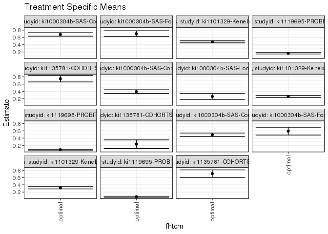

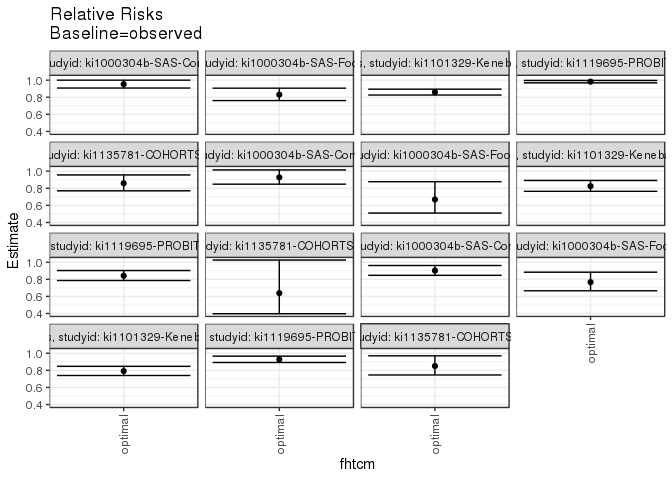

## Results Table

### Parameter: TSM

| agecat | studyid | country | intervention_level | baseline_level | estimate | ci_lower | ci_upper |
| --- | --- | --- | --- | --- | --- | --- | --- |
| 0-24 months | ki1000304b-SAS-CompFeed | INDIA | optimal | NA | 0.6817544 | 0.6348948 | 0.7286140 |
| 0-24 months | ki1000304b-SAS-FoodSuppl | INDIA | optimal | NA | 0.7036727 | 0.6255867 | 0.7817588 |
| 0-24 months | ki1101329-Keneba | GAMBIA | optimal | NA | 0.4794380 | 0.4512692 | 0.5076069 |
| 0-24 months | ki1119695-PROBIT | BELARUS | optimal | NA | 0.1638570 | 0.1457418 | 0.1819723 |
| 0-24 months | ki1135781-COHORTS | GUATEMALA | optimal | NA | 0.7475836 | 0.6600182 | 0.8351490 |
| 0-6 months | ki1000304b-SAS-CompFeed | INDIA | optimal | NA | 0.3930962 | 0.3420192 | 0.4441732 |
| 0-6 months | ki1000304b-SAS-FoodSuppl | INDIA | optimal | NA | 0.2608926 | 0.1807371 | 0.3410482 |
| 0-6 months | ki1101329-Keneba | GAMBIA | optimal | NA | 0.2586582 | 0.2311098 | 0.2862067 |
| 0-6 months | ki1119695-PROBIT | BELARUS | optimal | NA | 0.0824719 | 0.0695483 | 0.0953955 |
| 0-6 months | ki1135781-COHORTS | GUATEMALA | optimal | NA | 0.2334325 | 0.1159022 | 0.3509629 |
| 6-24 months | ki1000304b-SAS-CompFeed | INDIA | optimal | NA | 0.4901820 | 0.4415843 | 0.5387797 |
| 6-24 months | ki1000304b-SAS-FoodSuppl | INDIA | optimal | NA | 0.5907089 | 0.4832822 | 0.6981357 |
| 6-24 months | ki1101329-Keneba | GAMBIA | optimal | NA | 0.3174735 | 0.2865380 | 0.3484090 |
| 6-24 months | ki1119695-PROBIT | BELARUS | optimal | NA | 0.0718165 | 0.0584039 | 0.0852291 |
| 6-24 months | ki1135781-COHORTS | GUATEMALA | optimal | NA | 0.7070520 | 0.6045002 | 0.8096037 |

### Parameter: E(Y)

| agecat | studyid | country | intervention_level | baseline_level | estimate | ci_lower | ci_upper |
| --- | --- | --- | --- | --- | --- | --- | --- |
| 0-24 months | ki1000304b-SAS-CompFeed | INDIA | observed | NA | 0.7155202 | 0.6729219 | 0.7581185 |
| 0-24 months | ki1000304b-SAS-FoodSuppl | INDIA | observed | NA | 0.8473037 | 0.8119482 | 0.8826592 |
| 0-24 months | ki1101329-Keneba | GAMBIA | observed | NA | 0.5578045 | 0.5356251 | 0.5799839 |
| 0-24 months | ki1119695-PROBIT | BELARUS | observed | NA | 0.1668277 | 0.1481468 | 0.1855086 |
| 0-24 months | ki1135781-COHORTS | GUATEMALA | observed | NA | 0.8709777 | 0.8414455 | 0.9005099 |
| 0-6 months | ki1000304b-SAS-CompFeed | INDIA | observed | NA | 0.4237493 | 0.3896137 | 0.4578849 |
| 0-6 months | ki1000304b-SAS-FoodSuppl | INDIA | observed | NA | 0.3901365 | 0.3420876 | 0.4381854 |
| 0-6 months | ki1101329-Keneba | GAMBIA | observed | NA | 0.3133219 | 0.2914455 | 0.3351983 |
| 0-6 months | ki1119695-PROBIT | BELARUS | observed | NA | 0.0979142 | 0.0846096 | 0.1112187 |
| 0-6 months | ki1135781-COHORTS | GUATEMALA | observed | NA | 0.3658293 | 0.3143529 | 0.4173057 |
| 6-24 months | ki1000304b-SAS-CompFeed | INDIA | observed | NA | 0.5432500 | 0.5014364 | 0.5850636 |
| 6-24 months | ki1000304b-SAS-FoodSuppl | INDIA | observed | NA | 0.7702539 | 0.7165873 | 0.8239204 |
| 6-24 months | ki1101329-Keneba | GAMBIA | observed | NA | 0.4010925 | 0.3749260 | 0.4272590 |
| 6-24 months | ki1119695-PROBIT | BELARUS | observed | NA | 0.0773532 | 0.0634602 | 0.0912463 |
| 6-24 months | ki1135781-COHORTS | GUATEMALA | observed | NA | 0.8312126 | 0.7930474 | 0.8693778 |

### Parameter: RR

| agecat | studyid | country | intervention_level | baseline_level | estimate | ci_lower | ci_upper |
| --- | --- | --- | --- | --- | --- | --- | --- |
| 0-24 months | ki1000304b-SAS-CompFeed | INDIA | optimal | observed | 0.9528094 | 0.9079158 | 0.9999229 |
| 0-24 months | ki1000304b-SAS-FoodSuppl | INDIA | optimal | observed | 0.8304847 | 0.7612900 | 0.9059686 |
| 0-24 months | ki1101329-Keneba | GAMBIA | optimal | observed | 0.8595091 | 0.8260734 | 0.8942981 |
| 0-24 months | ki1119695-PROBIT | BELARUS | optimal | observed | 0.9821930 | 0.9682098 | 0.9963781 |
| 0-24 months | ki1135781-COHORTS | GUATEMALA | optimal | observed | 0.8583269 | 0.7704753 | 0.9561956 |
| 0-6 months | ki1000304b-SAS-CompFeed | INDIA | optimal | observed | 0.9276621 | 0.8480506 | 1.0147471 |
| 0-6 months | ki1000304b-SAS-FoodSuppl | INDIA | optimal | observed | 0.6687215 | 0.5099130 | 0.8769897 |
| 0-6 months | ki1101329-Keneba | GAMBIA | optimal | observed | 0.8255350 | 0.7644252 | 0.8915300 |
| 0-6 months | ki1119695-PROBIT | BELARUS | optimal | observed | 0.8422875 | 0.7859647 | 0.9026465 |
| 0-6 months | ki1135781-COHORTS | GUATEMALA | optimal | observed | 0.6380914 | 0.3971444 | 1.0252207 |
| 6-24 months | ki1000304b-SAS-CompFeed | INDIA | optimal | observed | 0.9023139 | 0.8465770 | 0.9617203 |
| 6-24 months | ki1000304b-SAS-FoodSuppl | INDIA | optimal | observed | 0.7669016 | 0.6658905 | 0.8832354 |
| 6-24 months | ki1101329-Keneba | GAMBIA | optimal | observed | 0.7915218 | 0.7396122 | 0.8470748 |
| 6-24 months | ki1119695-PROBIT | BELARUS | optimal | observed | 0.9284230 | 0.8919987 | 0.9663348 |
| 6-24 months | ki1135781-COHORTS | GUATEMALA | optimal | observed | 0.8506271 | 0.7458935 | 0.9700667 |